# Price Prediction for AirBnb Business in Melbourne

```
     Data Analysis 3
MS in Business Analytics
    2023/2024 Winter

   by Péter Szilvási
```

# Technical Report

**Aim of the document:**The report focuses on the technical aspects of the data cleaning, feature engineering, and model selection process of the assignment.

**GitHub:** [Codes and Data are available on my GitHub](https://github.com/szilvasipeter2000/Data-Analysis-3/tree/main/assignment-2)

**Business Goal:** Help build a price prediction model for a company operating small and mid-size apartments hosting 2-6 guests. This is done by first constructing a Lasso Model to select the best feature variables, then building an OLS model using Cross Validation, a Random Forest, and a Gradient Boosting Model. Finally I will compare the model performances and give ideas how to further improve the model.

## About the Data

**Data Source:**

**Download:** [Inside Airbnb](http://data.insideairbnb.com/australia/vic/melbourne/2023-09-04/data/listings.csv.gz)

**Melbourne Data:** [Explore Melbourne Inside Airbnb](http://insideairbnb.com/melbourne)

# Data Cleaning

Initially the dataset contains 23,185 observations and 75 columns.

**Dropping Unnecessary columns**

These are mainly NAs,empty lists, urls, ids, or simpy variables that are just non relevant for the analysis. The Result is only 33 columns left.

### Clean the Explanatory, `price`, Variable

```python
# formatting price column
listings['price'] = pd.to_numeric(listings['price'].replace('[\$,]', '', regex=True), errors='coerce')

# drop where price is missing
listings = listings.dropna(subset=['price'])
```

### Rename Room types, clean `bathroom_text` column from dirty str to float

```python
# def function to clean the bathroom text, split and space and set to int, if not possible set to 1
def clean_bathroom(text):
    try:
        return float(text.split(" ")[0])
    except:
        return text == 1 # the only missing was shared bath and Half-bath, which we can set to be 1

# apply function to the column
listings["bathrooms"] = listings["bathrooms_text"].apply(clean_bathroom)
listings.drop(columns="bathrooms_text", inplace=True)
```

### Clean `amenities` Column

- Instead of strings that inpersonate lists, create lists
- Create Unique list of amenities (3946 values)
- Export to Excel, to better Categorize each amenity and have more data points on observations
- Read the excel file, map back the original amenities
- Create dummy variables for all 72 amenity categories

```python
# after excel work import file from github
amenities_mapping = pd.read_csv("https://raw.githubusercontent.com/szilvasipeter2000/Data-Analysis-3/main/assignment-2/data/amenities_mapping.csv",delimiter=";")
# it looks like the following:
amenities_sample
```

|  | amenities | new |
| --- | --- | --- |
| 0 | Aveda conditioner | soap_shampoo |
| 1 | electric electric stove | stove |
| 2 | micro | microwave |
| 3 | Natural body soap | soap_shampoo |
| 4 | Normal shampoo | soap_shampoo |
| 5 | Samsung refrigerator | fridge |
| 6 | & AUD$2.50 d\u014dTERRA Body Moisturisers bod... | soap_shampoo |
| 7 | & Sukin shampoo | soap_shampoo |
| 8 | . conditioner | soap_shampoo |
| 9 | . shampoo | soap_shampoo |

```python
dummy_desc
```

|  | d_freeparking | d_ | d_airconditioning | d_kitchen_equipment | d_alarm | d_microwave | d_other | d_garage | d_smoking | d_cleaning | ... | d_dryer | d_fruit | d_balcony | d_soundsystem | d_firstaidkit | d_breakfast | d_rooftop | d_resortaccess | d_wifi | d_workspace |
| --- | --- | --- | --- | --- | --- | --- | --- | --- | --- | --- | --- | --- | --- | --- | --- | --- | --- | --- | --- | --- | --- |
| count | 11325.000000 | 11325.000000 | 11325.000000 | 11325.000000 | 11325.000000 | 11325.000000 | 11325.000000 | 11325.000000 | 11325.000000 | 11325.000000 | ... | 11325.000000 | 11325.0 | 11325.000000 | 11325.000000 | 11325.000000 | 11325.000000 | 11325.000000 | 11325.000000 | 11325.000000 | 11325.000000 |
| mean | 0.618102 | 0.000353 | 0.917528 | 0.993907 | 0.958234 | 0.682737 | 0.904547 | 0.032494 | 0.044327 | 0.075762 | ... | 0.867373 | 0.0 | 0.499161 | 0.070022 | 0.327506 | 0.059956 | 0.004503 | 0.018190 | 0.933775 | 0.411038 |
| std | 0.485873 | 0.018791 | 0.275095 | 0.077821 | 0.200063 | 0.465431 | 0.293852 | 0.177317 | 0.205829 | 0.264628 | ... | 0.339186 | 0.0 | 0.500021 | 0.255195 | 0.469324 | 0.237416 | 0.066958 | 0.133643 | 0.248686 | 0.492044 |
| min | 0.000000 | 0.000000 | 0.000000 | 0.000000 | 0.000000 | 0.000000 | 0.000000 | 0.000000 | 0.000000 | 0.000000 | ... | 0.000000 | 0.0 | 0.000000 | 0.000000 | 0.000000 | 0.000000 | 0.000000 | 0.000000 | 0.000000 | 0.000000 |
| 25% | 0.000000 | 0.000000 | 1.000000 | 1.000000 | 1.000000 | 0.000000 | 1.000000 | 0.000000 | 0.000000 | 0.000000 | ... | 1.000000 | 0.0 | 0.000000 | 0.000000 | 0.000000 | 0.000000 | 0.000000 | 0.000000 | 1.000000 | 0.000000 |
| 50% | 1.000000 | 0.000000 | 1.000000 | 1.000000 | 1.000000 | 1.000000 | 1.000000 | 0.000000 | 0.000000 | 0.000000 | ... | 1.000000 | 0.0 | 0.000000 | 0.000000 | 0.000000 | 0.000000 | 0.000000 | 0.000000 | 1.000000 | 0.000000 |
| 75% | 1.000000 | 0.000000 | 1.000000 | 1.000000 | 1.000000 | 1.000000 | 1.000000 | 0.000000 | 0.000000 | 0.000000 | ... | 1.000000 | 0.0 | 1.000000 | 0.000000 | 1.000000 | 0.000000 | 0.000000 | 0.000000 | 1.000000 | 1.000000 |
| max | 1.000000 | 1.000000 | 1.000000 | 1.000000 | 1.000000 | 1.000000 | 1.000000 | 1.000000 | 1.000000 | 1.000000 | ... | 1.000000 | 0.0 | 1.000000 | 1.000000 | 1.000000 | 1.000000 | 1.000000 | 1.000000 | 1.000000 | 1.000000 |

8 rows × 72 columns

# Feature Engineering

### Flagging and Imputing

Creating Flag Variables and Imputing Missing Values for Columns that are not as important or where it's not missing for a lot of observations.

More important variables will be dropped if missing

```python
# first create flags for missing variables, then input with median.

listings = listings.assign(
    # flag for beds
    flag_beds=np.multiply(listings.beds.isna(), 1),
    beds=listings.beds.fillna(np.median(listings.beds.dropna())),
    # flag for bathrooms
    flag_bathrooms=np.multiply(listings.bathrooms.isna(), 1),
    bathrooms=listings.bathrooms.fillna(np.median(listings.bathrooms.dropna())),
    # flag for cleaniness reviews
    flag_review_scores_cleanliness=np.multiply(listings.review_scores_cleanliness.isna(), 1),
    review_scores_cleanliness=listings.review_scores_cleanliness.fillna(
        np.median(listings.review_scores_cleanliness.dropna())),
    # flag for review score
    flag_review_scores_rating=np.multiply(listings.review_scores_rating.isna(), 1),
    review_scores_rating=listings.review_scores_rating.fillna(
        np.median(listings.review_scores_rating.dropna())),
    # flag for reviews per month
    flag_reviews_per_month=np.multiply(listings.reviews_per_month.isna(), 1),
    reviews_per_month=listings.reviews_per_month.fillna(
        np.median(listings.reviews_per_month.dropna())),
    # flag for number of reviews
    flag_number_of_reviews=np.multiply(listings.number_of_reviews.isna(), 1),
    number_of_reviews=listings.number_of_reviews.fillna(
        np.median(listings.number_of_reviews.dropna())),
    # flag for checkin reviews
    flag_review_scores_checkin=np.multiply(listings.review_scores_checkin.isna(), 1),
    review_scores_checkin=listings.review_scores_checkin.fillna(
        np.median(listings.review_scores_checkin.dropna())),
    # flag for communication reviews
    flag_review_scores_communication=np.multiply(listings.review_scores_communication.isna(), 1),
    review_scores_communication=listings.review_scores_communication.fillna(
        np.median(listings.review_scores_communication.dropna())),
    # flag for location reviews
    flag_review_scores_location=np.multiply(listings.review_scores_location.isna(), 1),
    review_scores_location=listings.review_scores_location.fillna(
        np.median(listings.review_scores_location.dropna())),
    # flag for value reviews
    flag_review_scores_value=np.multiply(listings.review_scores_value.isna(), 1),
    review_scores_value=listings.review_scores_value.fillna(
        np.median(listings.review_scores_value.dropna())),
    )
```

### Group `property_type` variable

```python
# define set of good property types, that fit the business needs
propertytypes = ["Entire rental unit",
                 "Private room in rental unit",
                 "Entire home",
                 "Entire condo",
                 "Private room in home",
                 "Apartment",
                 "House",
                 "Townhouse",
                 "Shared room in rental unit"]

# keep if property type is in the set
listings = listings.loc[lambda x: x["property_type"].isin(propertytypes)]

# rename to Rental unit or House
listings['property_type'] = listings['property_type'].apply(lambda x: 'Rental Unit' if "rental unit" in x else 'House')
```

```python
property_type_counts
```

```
Rental Unit    8624
House          2701
Name: property_type, dtype: int64
```

### Drop missing or outlier variables for `bedrooms` and `bathrooms`

```python
listings = listings.dropna(subset=['bedrooms'])
listings=listings.loc[listings.bathrooms < 8] # the apartments we want to price would not have this many bathrooms
```

Dropped 4963 rows due to missing bedrooms

### Pool variables together

- `bathrooms`
- `minimum_nights`
- `number_of_reviews`
- `availability_365`

```python
# Pool bathrooms with 0,1,2,10 bathrooms
bins = pd.IntervalIndex.from_tuples([(0, 1), (1, 2), (2, 7)], closed="left")
f_bath = pd.cut(listings["bathrooms"].to_list(), bins, labels=["0", "1", "2"])
f_bath.categories = [0, 1, 2]
listings["bathrooms"] = f_bath
```

```python
bathrooms_counts
```

```
1    8535
2    2785
0       5
Name: bathrooms, dtype: int64
```

```python
# Pool and categorize the number of minimum nights: 1,2,3, 3+

bins = pd.IntervalIndex.from_tuples(
    [(1, 2), (2, 3), (3, max(listings.minimum_nights))], closed="left"
)
f_min_n = pd.cut(listings["minimum_nights"].to_list(), bins, labels=["1", "2", "3"])
f_min_n.categories = [1, 2, 3]
listings["minimum_nights"] = f_min_n
```

```python
minimum_nights_counts
```

```
2    4106
3    4012
1    3207
Name: minimum_nights, dtype: int64
```

```python
# Pool num of reviews to 3 categories: none, 1-51 and >51

bins = pd.IntervalIndex.from_tuples(
    [(0, 1), (1, 51), (51, max(listings.number_of_reviews))], closed="left"
)
fnor = pd.cut(listings["number_of_reviews"].to_list(), bins, labels=["0", "1", "2"])
fnor.categories = [0, 1, 2]
listings["number_of_reviews"] = fnor
```

```python
number_of_reviews_counts
```

```
1    7336
2    2263
0    1726
Name: number_of_reviews, dtype: int64
```

```python
# Pool availability 365 to 4 categories: 1-51,51-151,151-251, >251

bins = pd.IntervalIndex.from_tuples(
    [(0, 51), (51, 151), (151, 251), (251, max(listings.availability_365))], closed="left"
)

fnor = pd.cut(listings["availability_365"].to_list(), bins, labels=["0", "1", "2", "3"])
fnor.categories = [0, 1, 2, 3]
listings["availability_365"] = fnor
```

```python
availability_365_counts
```

```
0    4032
1    2956
3    2666
2    1671
Name: availability_365, dtype: int64
```

# Exploratory Data Analysis (EDA):

```python
listings['price'].describe(percentiles=[0.25, 0.5, 0.75,0.85, 0.9, 0.95, 0.99])
```

[output not shown]

```python
# drop unreasonable prices
listings = listings[listings['price'] <= 400]
```

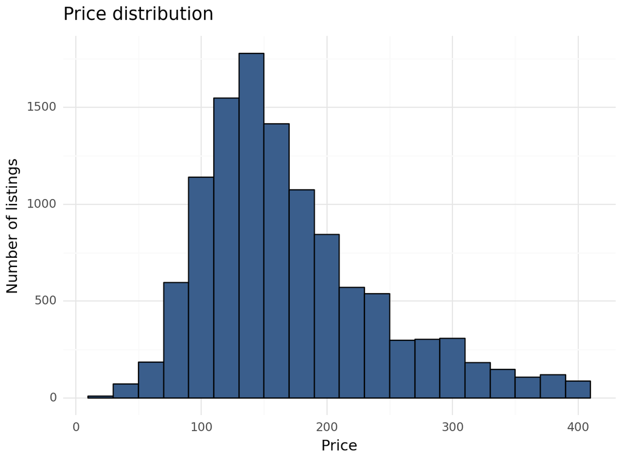

```
<Figure Size: (640 x 480)>
```

```python
ggplot(listings) + \
    aes(x='price') + \
    geom_histogram(binwidth=20, color='black', fill=color[0]) + \
    theme_minimal() + \
    labs(title='Price distribution', x='Price', y='Number of listings')
```

Since our price distribution is skewed to the right, our Models going to have quite high RMSE values.

If we were to filter for only lower valus of price, our RMSEs would decrase.

```python
# drop not fitting values for accomodates
listings=listings.loc[listings.accommodates < 7]

# drop not fitting values for beds
listings = listings.loc[listings.beds > 0]

# drop missing values for remaining columns
listings = listings.dropna(subset = ["availability_365","minimum_nights","number_of_reviews", "bathrooms"])
```

We still have 11,325 observations, which is sufficient to build models

```python
# How is the price distributed for different number of accommodates?
listings.groupby(["accommodates"]).agg(mean_price=("price", np.mean))
```

| accommodates | mean_price |
| --- | --- |
| 1 | 99.488636 |
| 2 | 141.859182 |
| 3 | 147.666667 |
| 4 | 179.564145 |
| 5 | 197.394144 |
| 6 | 227.596469 |

```python
#How is the average price changing in my district by `property_type`, `room_type`?
listings.groupby(["property_type", "room_type"]).agg(mean_price=("price", np.mean))
```

| property_type | room_type | mean_price |
| --- | --- | --- |
| House | Entire | 201.663385 |
|  | Private | 78.900000 |
| Rental Unit | Entire | 164.568097 |
|  | Private | 103.083333 |

```python
# What is the correlation between availability of the AirBnb and its Price?
listings.groupby("availability_365").agg(mean_price=("price", np.mean))
```

| availability_365 | mean_price |
| --- | --- |
| 0 | 154.825149 |
| 1 | 168.964479 |
| 2 | 184.152005 |
| 3 | 195.866092 |

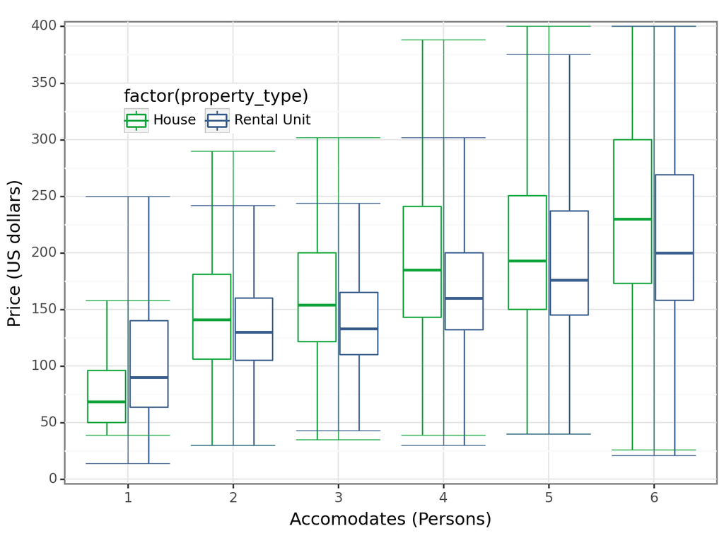

```
<Figure Size: (640 x 480)>
```

```python
(
    ggplot(
        listings,
        aes(
            x="factor(accommodates)",
            y="price",
            # fill="factor(f_property_type)",
            color="factor(property_type)",
        ),
    )
    + geom_boxplot(alpha=0.8, na_rm=True, outlier_shape="", width=0.8, stat="boxplot")
    + stat_boxplot(geom="errorbar", width=0.8, size=0.3, na_rm=True)
    + scale_color_manual(name="", values=(color[1], color[0]))
    + scale_fill_manual(name="", values=(color[1], color[0]))
    + labs(x="Accomodates (Persons)", y="Price (US dollars)")
    + scale_y_continuous(expand=(0.01, 0.01), limits=(0, 400), breaks=seq(0, 401, 50))
    + theme_bw()
    + theme(legend_position=(0.3, 0.8))
)
```

# Variable Selection

Define set of variables to use in the prediction models

```python
basic_lev = (
    "accommodates",
    "beds",
    "flag_beds",
    "property_type",
    "room_type",
    "bedrooms")

basic_add = ("bathrooms",
             "flag_bathrooms",
             "neighbourhood_cleansed",
             "availability_365",
             "minimum_nights")

reviews = ("number_of_reviews",
           "flag_number_of_reviews",
           "reviews_per_month",
           "flag_reviews_per_month",
           "review_scores_rating",
           "flag_review_scores_rating")

more_reviews = ("review_scores_cleanliness",
                "flag_review_scores_cleanliness",
                "review_scores_checkin",
                "flag_review_scores_checkin",
                "review_scores_communication",
                "flag_review_scores_communication",
                "review_scores_location",
                "flag_review_scores_location",
                "review_scores_value",
                "flag_review_scores_value")

amenity_columns = tuple([col for col in listings.columns if col.startswith("d_")])
```

# LASSO Model for Interaction Selection:

Lasso is mainly used for feature selection, as it shrinks the coefficients of less important features to exactly 0. This is useful for feature selection, as it can be used to remove less important features from the model. Will also include lots of interactions so in the end we can see which interactions are important.

```python
# define model evaluation method
cv = RepeatedKFold(n_splits=5, n_repeats=1, random_state=1)
smp_size = round(0.2 * listings.shape[0])-1
y, X = patsy.dmatrices("price" + modellev8, listings) # use the most complex model
```

The most complex model takes 17 minutes, 41 seconds to run

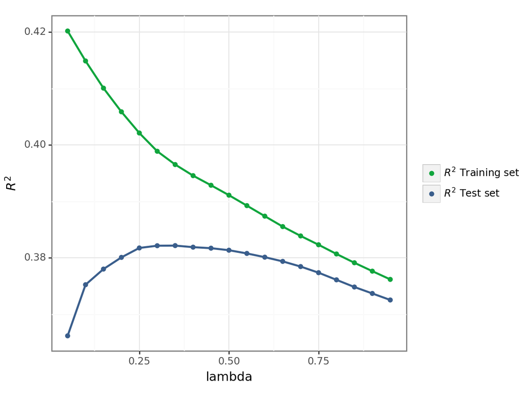

```
<Figure Size: (640 x 480)>
```

```python
(
    ggplot(r_squared_data, aes(x="lambda", y="value", color="variable"))
    + geom_point()
    + geom_line(size=1, show_legend=False, na_rm=True)
    + scale_color_manual(name="", values=(color[1], color[0]))
    + scale_y_continuous(name="$R^2$")
    + theme_bw()
    + theme(subplots_adjust={"wspace": 0.25},legend_title=element_blank())
)
```

The most complex model is optimal at lambda equal to 0.35, where the R squared of the Test set peaks at 38.22.

In this model we included all dummies with interactions to all the categorical features.

It turned out that the only good interaction is the `room_type*property_type` which has a coefficient of 1.886.

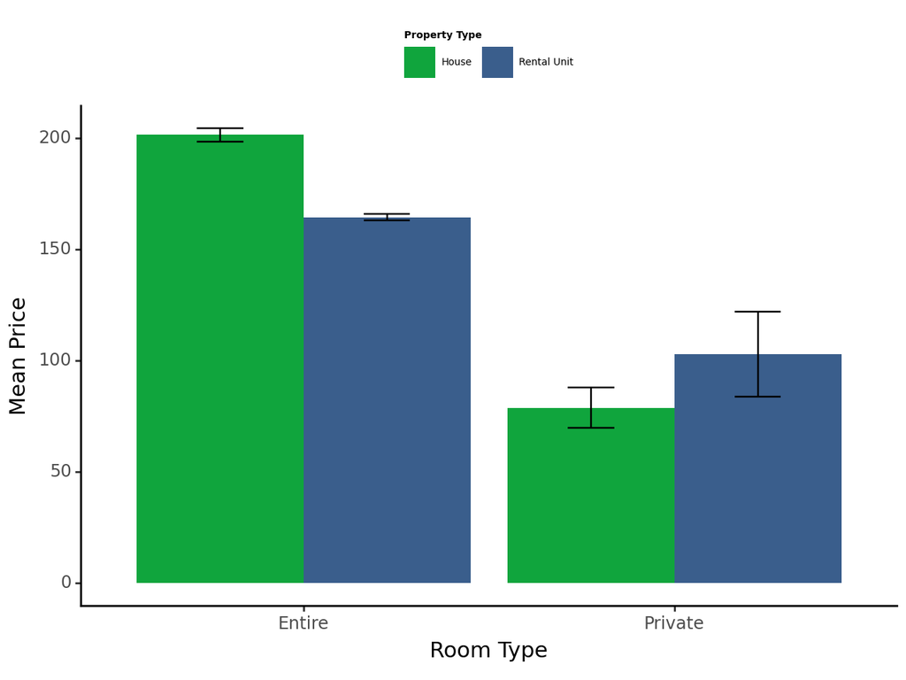

```
<Figure Size: (640 x 480)>
```

```python
price_diff_by_variables(
    listings,
    "room_type",
    "property_type",
    "Room Type",
    "Property Type",
)
```

# OLS Model: Regression with Cross-Validation

```python
X1 = "room_type:property_type"
modellev1 = "~ accommodates"
modellev2 = "~" + "+".join(basic_lev)
modellev3 = "~" + "+".join(basic_lev) + "+" + "+".join(basic_add)
modellev4 = "~" + "+".join(basic_lev) + "+" + "+".join(basic_add) + "+" + "+".join(reviews)
modellev5 = "~" + "+".join(basic_lev) + "+" + "+".join(basic_add) + "+" + "+".join(reviews)+ "+" + "+".join(more_reviews)+ "+" + "+" + X1
modellev6 = "~" + "+".join(basic_lev) + "+" + "+".join(basic_add) + "+" + "+".join(reviews)+ "+" + "+".join(more_reviews)+ "+" + "+" + X1+ "+" + "+".join(amenity_columns)
```

```python
ols_cv
```

|  | Model1 | Model2 | Model3 | Model4 | Model5 | Model6 |
| --- | --- | --- | --- | --- | --- | --- |
| Fold1 | 64.899480 | 63.019852 | 58.982854 | 58.200083 | 57.757140 | 55.414879 |
| Fold2 | 65.442514 | 63.591983 | 59.407766 | 58.617170 | 58.249169 | 56.047885 |
| Fold3 | 65.266205 | 63.624287 | 59.258197 | 58.642015 | 58.195775 | 56.129058 |
| Fold4 | 64.206392 | 62.539480 | 58.043913 | 57.595930 | 57.109600 | 55.045141 |
| Fold5 | 66.399628 | 64.697655 | 60.071116 | 59.131401 | 58.450484 | 56.060081 |
| Average | 65.242844 | 63.494652 | 59.152769 | 58.437320 | 57.952434 | 55.739409 |

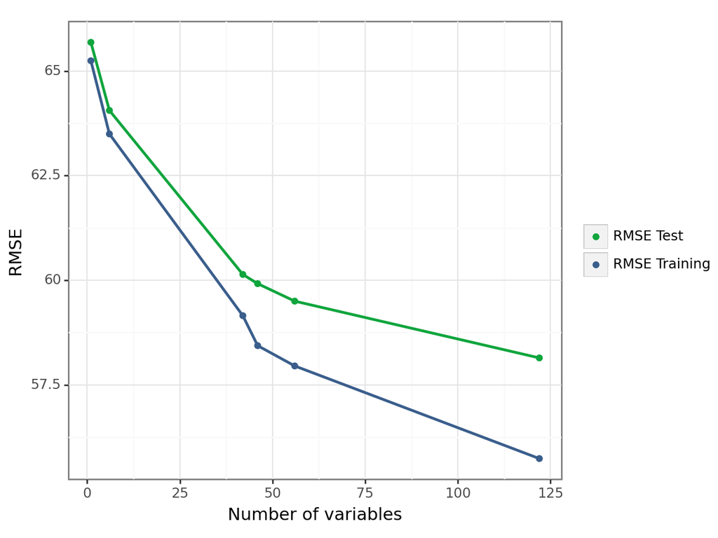

```
<Figure Size: (640 x 480)>
```

```python
(
    ggplot(ols_graph_df, aes(x="nvars", y="value", color="var"))
    + geom_point()
    + geom_line(size=1, show_legend=False, na_rm=True)
    + scale_color_manual(name="", values=(color[1], color[0]))
    + scale_y_continuous(name="RMSE")
    + labs(x="Number of variables")
    + theme_bw()
    + theme(subplots_adjust={"wspace": 0.25},legend_title=element_blank())
)
```

Here we can see the improvements made by adding extra variables. Even the simplest model only has an RMSE of around 65. There is a significant increase from model 2 to 3, where we add bathrooms, neighbourhoods, availability thorughout the year and minimum nights.

An interesting part when addig the dummies, the Test and Training RMSE starts to diverge from each other. This could be a sign of early overfitting. The training data learns the patterns too well, capturing noise in the process.Even after this, the most complex model is still the best performing with almost 125 variables.

# Random Forest

Our training data has 9060 observations while our houldout has 2265, based on the 80-20 rule.

The model is using the same variables as the OLS model, without the interactions.

The theoretical recommended number of variables is 11.53. So we will use max features of 12.

```python
forest_df
```

| min node size max features | 5 | 10 | 15 |
| --- | --- | --- | --- |
| 6 | 57.69 | 58.61 | 59.26 |
| 8 | 56.78 | 57.77 | 58.36 |
| 10 | 56.44 | 57.46 | 58.03 |
| 12 | 56.03 | 57.05 | 57.64 |

It shows that the best parameters for the model is 12 max features and 5 min sample leaves.

This generates an RMSE of 56.03

```python
# we can look at variable importance
df_var_importance["imp"] = df_var_importance["imp"].apply(lambda x: f"{x*100:.2f}%")
df_var_importance["cumulative_imp"] = df_var_importance["cumulative_imp"].apply(lambda x: f"{x*100:.2f}%")
df_var_importance.head(35)
```

|  | variable | imp | cumulative_imp |
| --- | --- | --- | --- |
| 0 | bedrooms | 8.37% | 8.37% |
| 1 | accommodates | 7.93% | 16.30% |
| 2 | bathrooms[T.1] | 6.74% | 23.04% |
| 3 | beds | 5.98% | 29.02% |
| 4 | bathrooms[T.2] | 5.76% | 34.79% |
| 5 | reviews_per_month | 4.17% | 38.96% |
| 6 | availability_365[T.3] | 3.21% | 42.17% |
| 7 | review_scores_rating | 3.10% | 45.27% |
| 8 | review_scores_cleanliness | 2.81% | 48.08% |
| 9 | d_outdoors | 2.52% | 50.60% |
| 10 | review_scores_location | 2.40% | 52.99% |
| 11 | review_scores_communication | 2.28% | 55.27% |
| 12 | review_scores_value | 2.26% | 57.53% |
| 13 | review_scores_checkin | 2.04% | 59.57% |
| 14 | d_bathtub | 1.48% | 61.05% |
| 15 | d_kidfriendly | 1.39% | 62.44% |
| 16 | property_type[T.Rental Unit] | 1.32% | 63.76% |
| 17 | d_bbq | 1.22% | 64.98% |
| 18 | neighbourhood_cleansed[T.Yarra Ranges] | 1.09% | 66.07% |
| 19 | d_fireplace | 0.98% | 67.05% |
| 20 | d_fireextinguisher | 0.94% | 67.99% |
| 21 | d_chair | 0.94% | 68.93% |
| 22 | d_firstaidkit | 0.91% | 69.85% |
| 23 | d_workspace | 0.90% | 70.75% |
| 24 | d_freeparking | 0.83% | 71.58% |
| 25 | d_petfriendly | 0.79% | 72.36% |
| 26 | d_view | 0.78% | 73.14% |
| 27 | d_elevator | 0.78% | 73.93% |
| 28 | minimum_nights[T.3] | 0.78% | 74.71% |
| 29 | d_coffee | 0.77% | 75.48% |
| 30 | d_backyard | 0.77% | 76.25% |
| 31 | d_table | 0.73% | 76.98% |
| 32 | minimum_nights[T.2] | 0.71% | 77.69% |
| 33 | d_selfcheckin | 0.69% | 78.38% |
| 34 | neighbourhood_cleansed[T.Melbourne] | 0.67% | 79.05% |

The most important variable according to the random forest model is bedrooms. If we were to neglect this variable, our prediction accuracy would decrease by 8.37%. Accomodates, number of bathrooms, number of beds are following closely, just as reviews per month. Also including the dummy variables was a good choice as starting with whether the airbnb has outdoor opportunities helps the model with 2.52% prediction accuracy. It might not sound much but there are 17 dummy variables in the top 35, which is included in the technical report

# GBM model

The GBM model also uses the same variables as the Random Forest and the OLS.

The best estimatores for the model are, max depth equal to 5, max features 10, minimum sample split 20, while number of estimators equal to 300.

With this, the prediction has an RMSE of 52.73.

# Comparing Results

```python
comparing_results
```

|  | Model | RMSE |
| --- | --- | --- |
| 0 | Gradient Boosting Model | 52.731020 |
| 1 | Random Forest | 56.030508 |
| 2 | Lasso OLS | 56.701704 |
| 3 | OLS CV | 58.144098 |

In the comparison of the different models, we can compare them based on the RMSE values.

The Gradient Boostings Model demonstrates the best performance with the lowest RMSE of 52.73. Following, the Random Forest model achieving an RMSE of 56.03. Close to this, our Lasso demonstrated 56.7, and lastly our OLS with Cross Validation using the interactions from the Lasso model achieved a not too good value of 58.14.

# Limitations

Note, that this is with a price range that is quite wide. If we were to narrow it down to 80th percentile instead of 90, we would get much lower RMSE values.

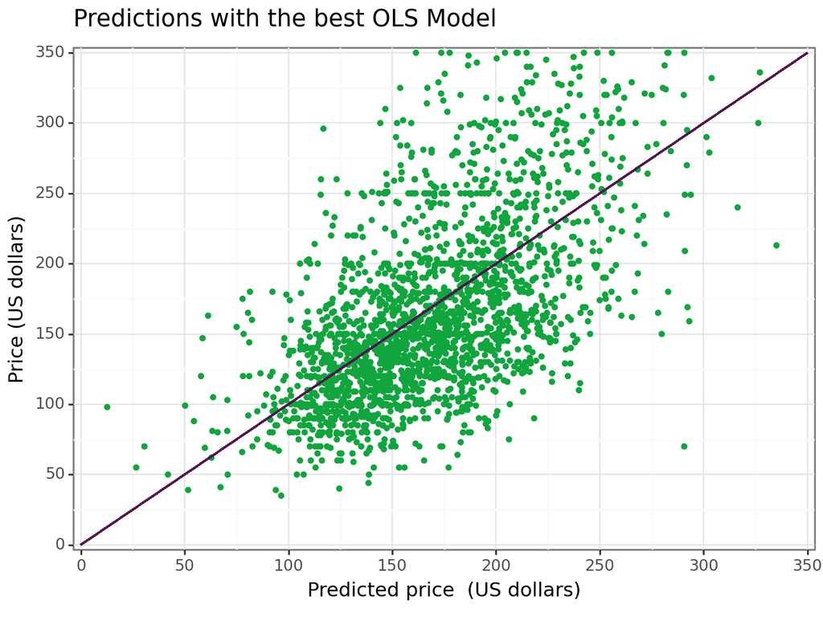

```
<Figure Size: (640 x 480)>
```

```python
(
    ggplot(data=data_diagnostic)
    + geom_point(
        aes(y="Ylev", x="mean"),
        color=color[1],
        size=1,
        alpha=0.7,
        show_legend=False,
        na_rm=True,
    )
    + geom_segment(aes(x=0, y=0, xend=350, yend=350), size=0.5, color=color[2])
    + coord_cartesian(xlim=(0, 350), ylim=(0, 350))
    + scale_x_continuous(
        expand=(0.01, 0.01), limits=(0, 350), breaks=seq(0, 350, by=50)
    )
    + scale_y_continuous(
        expand=(0.01, 0.01), limits=(0, 350), breaks=seq(0, 350, by=50)
    )
    + labs(title = "Predictions with the best OLS Model",y="Price (US dollars)", x="Predicted price  (US dollars)")
    + theme_bw()
)
```

On this graph, we can see that if we were to restrict our price variable to less than 250 or even lower, our mean square errors would drastically decrease. As for those values the predicted values are way closer to its actual value, while above 250, the predictions start to become lower from their actual values.

Just to see, these would be our values if we were to restrict our price column at the 80th percentile, that means that the price cannot be higher than 293 dollars.

```python
comparing_results
```

|  | Model | RMSE |
| --- | --- | --- |
| 0 | Gradient Boosting Model | 40.642169 |
| 1 | Random Forest | 42.841533 |
| 2 | Lasso OLS | 43.187603 |
| 3 | OLS CV | 44.155009 |

Our RMSE values drastically decreased. However the model performance order didn't change. Even with this filtering of the price variable, we still have above 10,000 observations, I just as a Data Analyst feel like restricting the prediction variable at its 80th percentile is too strict.